# Bike Sharing Data in Washington D.C.

## Exploring Ride Sharing and Weather

Now let's examine how the weather is affecting rider's behavior. First let's look at how the proportion of casual riders changes as weather changes.

Let's create a new column `prop_casual` in the `bike` dataframe representing the proportion of casual riders out of all riders.

```python
bike['prop_casual'] = bike['casual'] / (bike['casual'] + bike['registered'])
bike
```

|  | instant | dteday | season | yr | mnth | hr | holiday | weekday | workingday | weathersit | temp | atemp | hum | windspeed | casual | registered | cnt | Day of the Month | prop_casual |
| --- | --- | --- | --- | --- | --- | --- | --- | --- | --- | --- | --- | --- | --- | --- | --- | --- | --- | --- | --- |
| 0 | 1 | 2011-01-01 | 1 | 0 | 1 | 0 | no | Sat | no | Clear | 0.24 | 0.2879 | 0.81 | 0.0000 | 3 | 13 | 16 | 2011-01-01 | 0.187500 |
| 1 | 2 | 2011-01-01 | 1 | 0 | 1 | 1 | no | Sat | no | Clear | 0.22 | 0.2727 | 0.80 | 0.0000 | 8 | 32 | 40 | 2011-01-01 | 0.200000 |
| 2 | 3 | 2011-01-01 | 1 | 0 | 1 | 2 | no | Sat | no | Clear | 0.22 | 0.2727 | 0.80 | 0.0000 | 5 | 27 | 32 | 2011-01-01 | 0.156250 |
| 3 | 4 | 2011-01-01 | 1 | 0 | 1 | 3 | no | Sat | no | Clear | 0.24 | 0.2879 | 0.75 | 0.0000 | 3 | 10 | 13 | 2011-01-01 | 0.230769 |
| 4 | 5 | 2011-01-01 | 1 | 0 | 1 | 4 | no | Sat | no | Clear | 0.24 | 0.2879 | 0.75 | 0.0000 | 0 | 1 | 1 | 2011-01-01 | 0.000000 |
| 5 | 6 | 2011-01-01 | 1 | 0 | 1 | 5 | no | Sat | no | Mist | 0.24 | 0.2576 | 0.75 | 0.0896 | 0 | 1 | 1 | 2011-01-01 | 0.000000 |
| 6 | 7 | 2011-01-01 | 1 | 0 | 1 | 6 | no | Sat | no | Clear | 0.22 | 0.2727 | 0.80 | 0.0000 | 2 | 0 | 2 | 2011-01-01 | 1.000000 |
| 7 | 8 | 2011-01-01 | 1 | 0 | 1 | 7 | no | Sat | no | Clear | 0.20 | 0.2576 | 0.86 | 0.0000 | 1 | 2 | 3 | 2011-01-01 | 0.333333 |
| 8 | 9 | 2011-01-01 | 1 | 0 | 1 | 8 | no | Sat | no | Clear | 0.24 | 0.2879 | 0.75 | 0.0000 | 1 | 7 | 8 | 2011-01-01 | 0.125000 |
| 9 | 10 | 2011-01-01 | 1 | 0 | 1 | 9 | no | Sat | no | Clear | 0.32 | 0.3485 | 0.76 | 0.0000 | 8 | 6 | 14 | 2011-01-01 | 0.571429 |
| 10 | 11 | 2011-01-01 | 1 | 0 | 1 | 10 | no | Sat | no | Clear | 0.38 | 0.3939 | 0.76 | 0.2537 | 12 | 24 | 36 | 2011-01-01 | 0.333333 |
| 11 | 12 | 2011-01-01 | 1 | 0 | 1 | 11 | no | Sat | no | Clear | 0.36 | 0.3333 | 0.81 | 0.2836 | 26 | 30 | 56 | 2011-01-01 | 0.464286 |
| 12 | 13 | 2011-01-01 | 1 | 0 | 1 | 12 | no | Sat | no | Clear | 0.42 | 0.4242 | 0.77 | 0.2836 | 29 | 55 | 84 | 2011-01-01 | 0.345238 |
| 13 | 14 | 2011-01-01 | 1 | 0 | 1 | 13 | no | Sat | no | Mist | 0.46 | 0.4545 | 0.72 | 0.2985 | 47 | 47 | 94 | 2011-01-01 | 0.500000 |
| 14 | 15 | 2011-01-01 | 1 | 0 | 1 | 14 | no | Sat | no | Mist | 0.46 | 0.4545 | 0.72 | 0.2836 | 35 | 71 | 106 | 2011-01-01 | 0.330189 |
| 15 | 16 | 2011-01-01 | 1 | 0 | 1 | 15 | no | Sat | no | Mist | 0.44 | 0.4394 | 0.77 | 0.2985 | 40 | 70 | 110 | 2011-01-01 | 0.363636 |
| 16 | 17 | 2011-01-01 | 1 | 0 | 1 | 16 | no | Sat | no | Mist | 0.42 | 0.4242 | 0.82 | 0.2985 | 41 | 52 | 93 | 2011-01-01 | 0.440860 |
| 17 | 18 | 2011-01-01 | 1 | 0 | 1 | 17 | no | Sat | no | Mist | 0.44 | 0.4394 | 0.82 | 0.2836 | 15 | 52 | 67 | 2011-01-01 | 0.223881 |
| 18 | 19 | 2011-01-01 | 1 | 0 | 1 | 18 | no | Sat | no | Light | 0.42 | 0.4242 | 0.88 | 0.2537 | 9 | 26 | 35 | 2011-01-01 | 0.257143 |
| 19 | 20 | 2011-01-01 | 1 | 0 | 1 | 19 | no | Sat | no | Light | 0.42 | 0.4242 | 0.88 | 0.2537 | 6 | 31 | 37 | 2011-01-01 | 0.162162 |
| 20 | 21 | 2011-01-01 | 1 | 0 | 1 | 20 | no | Sat | no | Mist | 0.40 | 0.4091 | 0.87 | 0.2537 | 11 | 25 | 36 | 2011-01-01 | 0.305556 |
| 21 | 22 | 2011-01-01 | 1 | 0 | 1 | 21 | no | Sat | no | Mist | 0.40 | 0.4091 | 0.87 | 0.1940 | 3 | 31 | 34 | 2011-01-01 | 0.088235 |
| 22 | 23 | 2011-01-01 | 1 | 0 | 1 | 22 | no | Sat | no | Mist | 0.40 | 0.4091 | 0.94 | 0.2239 | 11 | 17 | 28 | 2011-01-01 | 0.392857 |
| 23 | 24 | 2011-01-01 | 1 | 0 | 1 | 23 | no | Sat | no | Mist | 0.46 | 0.4545 | 0.88 | 0.2985 | 15 | 24 | 39 | 2011-01-01 | 0.384615 |
| 24 | 25 | 2011-01-02 | 1 | 0 | 1 | 0 | no | Sun | no | Mist | 0.46 | 0.4545 | 0.88 | 0.2985 | 4 | 13 | 17 | 2011-01-02 | 0.235294 |
| 25 | 26 | 2011-01-02 | 1 | 0 | 1 | 1 | no | Sun | no | Mist | 0.44 | 0.4394 | 0.94 | 0.2537 | 1 | 16 | 17 | 2011-01-02 | 0.058824 |
| 26 | 27 | 2011-01-02 | 1 | 0 | 1 | 2 | no | Sun | no | Mist | 0.42 | 0.4242 | 1.00 | 0.2836 | 1 | 8 | 9 | 2011-01-02 | 0.111111 |
| 27 | 28 | 2011-01-02 | 1 | 0 | 1 | 3 | no | Sun | no | Mist | 0.46 | 0.4545 | 0.94 | 0.1940 | 2 | 4 | 6 | 2011-01-02 | 0.333333 |
| 28 | 29 | 2011-01-02 | 1 | 0 | 1 | 4 | no | Sun | no | Mist | 0.46 | 0.4545 | 0.94 | 0.1940 | 2 | 1 | 3 | 2011-01-02 | 0.666667 |
| 29 | 30 | 2011-01-02 | 1 | 0 | 1 | 6 | no | Sun | no | Light | 0.42 | 0.4242 | 0.77 | 0.2985 | 0 | 2 | 2 | 2011-01-02 | 0.000000 |
| ... | ... | ... | ... | ... | ... | ... | ... | ... | ... | ... | ... | ... | ... | ... | ... | ... | ... | ... | ... |
| 17349 | 17350 | 2012-12-30 | 1 | 1 | 12 | 18 | no | Sun | no | Mist | 0.24 | 0.2121 | 0.44 | 0.2985 | 12 | 113 | 125 | 2012-12-30 | 0.096000 |
| 17350 | 17351 | 2012-12-30 | 1 | 1 | 12 | 19 | no | Sun | no | Clear | 0.34 | 0.3636 | 0.61 | 0.0000 | 16 | 86 | 102 | 2012-12-30 | 0.156863 |
| 17351 | 17352 | 2012-12-30 | 1 | 1 | 12 | 20 | no | Sun | no | Clear | 0.22 | 0.1970 | 0.47 | 0.3284 | 9 | 63 | 72 | 2012-12-30 | 0.125000 |
| 17352 | 17353 | 2012-12-30 | 1 | 1 | 12 | 21 | no | Sun | no | Clear | 0.20 | 0.2121 | 0.51 | 0.1642 | 5 | 42 | 47 | 2012-12-30 | 0.106383 |
| 17353 | 17354 | 2012-12-30 | 1 | 1 | 12 | 22 | no | Sun | no | Clear | 0.20 | 0.1970 | 0.55 | 0.1940 | 6 | 30 | 36 | 2012-12-30 | 0.166667 |
| 17354 | 17355 | 2012-12-30 | 1 | 1 | 12 | 23 | no | Sun | no | Clear | 0.20 | 0.1970 | 0.51 | 0.2239 | 10 | 39 | 49 | 2012-12-30 | 0.204082 |
| 17355 | 17356 | 2012-12-31 | 1 | 1 | 12 | 0 | no | Mon | yes | Clear | 0.18 | 0.1818 | 0.55 | 0.1940 | 4 | 30 | 34 | 2012-12-31 | 0.117647 |
| 17356 | 17357 | 2012-12-31 | 1 | 1 | 12 | 1 | no | Mon | yes | Clear | 0.18 | 0.1818 | 0.55 | 0.1940 | 6 | 13 | 19 | 2012-12-31 | 0.315789 |
| 17357 | 17358 | 2012-12-31 | 1 | 1 | 12 | 2 | no | Mon | yes | Clear | 0.16 | 0.1667 | 0.59 | 0.1642 | 3 | 8 | 11 | 2012-12-31 | 0.272727 |
| 17358 | 17359 | 2012-12-31 | 1 | 1 | 12 | 3 | no | Mon | yes | Clear | 0.16 | 0.1818 | 0.59 | 0.1045 | 0 | 1 | 1 | 2012-12-31 | 0.000000 |
| 17359 | 17360 | 2012-12-31 | 1 | 1 | 12 | 4 | no | Mon | yes | Clear | 0.14 | 0.1667 | 0.69 | 0.1045 | 0 | 3 | 3 | 2012-12-31 | 0.000000 |
| 17360 | 17361 | 2012-12-31 | 1 | 1 | 12 | 5 | no | Mon | yes | Clear | 0.16 | 0.1515 | 0.64 | 0.1940 | 0 | 9 | 9 | 2012-12-31 | 0.000000 |
| 17361 | 17362 | 2012-12-31 | 1 | 1 | 12 | 6 | no | Mon | yes | Clear | 0.16 | 0.1667 | 0.64 | 0.1642 | 0 | 40 | 40 | 2012-12-31 | 0.000000 |
| 17362 | 17363 | 2012-12-31 | 1 | 1 | 12 | 7 | no | Mon | yes | Clear | 0.16 | 0.1818 | 0.64 | 0.1343 | 2 | 83 | 85 | 2012-12-31 | 0.023529 |
| 17363 | 17364 | 2012-12-31 | 1 | 1 | 12 | 8 | no | Mon | yes | Clear | 0.14 | 0.1515 | 0.69 | 0.1343 | 9 | 187 | 196 | 2012-12-31 | 0.045918 |
| 17364 | 17365 | 2012-12-31 | 1 | 1 | 12 | 9 | no | Mon | yes | Mist | 0.18 | 0.2121 | 0.64 | 0.1045 | 13 | 144 | 157 | 2012-12-31 | 0.082803 |
| 17365 | 17366 | 2012-12-31 | 1 | 1 | 12 | 10 | no | Mon | yes | Mist | 0.20 | 0.2121 | 0.69 | 0.1343 | 33 | 87 | 120 | 2012-12-31 | 0.275000 |
| 17366 | 17367 | 2012-12-31 | 1 | 1 | 12 | 11 | no | Mon | yes | Mist | 0.22 | 0.2273 | 0.60 | 0.1940 | 43 | 114 | 157 | 2012-12-31 | 0.273885 |
| 17367 | 17368 | 2012-12-31 | 1 | 1 | 12 | 12 | no | Mon | yes | Mist | 0.24 | 0.2273 | 0.56 | 0.1940 | 52 | 172 | 224 | 2012-12-31 | 0.232143 |
| 17368 | 17369 | 2012-12-31 | 1 | 1 | 12 | 13 | no | Mon | yes | Mist | 0.26 | 0.2576 | 0.44 | 0.1642 | 38 | 165 | 203 | 2012-12-31 | 0.187192 |
| 17369 | 17370 | 2012-12-31 | 1 | 1 | 12 | 14 | no | Mon | yes | Mist | 0.28 | 0.2727 | 0.45 | 0.2239 | 62 | 185 | 247 | 2012-12-31 | 0.251012 |
| 17370 | 17371 | 2012-12-31 | 1 | 1 | 12 | 15 | no | Mon | yes | Mist | 0.28 | 0.2879 | 0.45 | 0.1343 | 69 | 246 | 315 | 2012-12-31 | 0.219048 |
| 17371 | 17372 | 2012-12-31 | 1 | 1 | 12 | 16 | no | Mon | yes | Mist | 0.26 | 0.2576 | 0.48 | 0.1940 | 30 | 184 | 214 | 2012-12-31 | 0.140187 |
| 17372 | 17373 | 2012-12-31 | 1 | 1 | 12 | 17 | no | Mon | yes | Mist | 0.26 | 0.2879 | 0.48 | 0.0896 | 14 | 150 | 164 | 2012-12-31 | 0.085366 |
| 17373 | 17374 | 2012-12-31 | 1 | 1 | 12 | 18 | no | Mon | yes | Mist | 0.26 | 0.2727 | 0.48 | 0.1343 | 10 | 112 | 122 | 2012-12-31 | 0.081967 |
| 17374 | 17375 | 2012-12-31 | 1 | 1 | 12 | 19 | no | Mon | yes | Mist | 0.26 | 0.2576 | 0.60 | 0.1642 | 11 | 108 | 119 | 2012-12-31 | 0.092437 |
| 17375 | 17376 | 2012-12-31 | 1 | 1 | 12 | 20 | no | Mon | yes | Mist | 0.26 | 0.2576 | 0.60 | 0.1642 | 8 | 81 | 89 | 2012-12-31 | 0.089888 |
| 17376 | 17377 | 2012-12-31 | 1 | 1 | 12 | 21 | no | Mon | yes | Clear | 0.26 | 0.2576 | 0.60 | 0.1642 | 7 | 83 | 90 | 2012-12-31 | 0.077778 |
| 17377 | 17378 | 2012-12-31 | 1 | 1 | 12 | 22 | no | Mon | yes | Clear | 0.26 | 0.2727 | 0.56 | 0.1343 | 13 | 48 | 61 | 2012-12-31 | 0.213115 |
| 17378 | 17379 | 2012-12-31 | 1 | 1 | 12 | 23 | no | Mon | yes | Clear | 0.26 | 0.2727 | 0.65 | 0.1343 | 12 | 37 | 49 | 2012-12-31 | 0.244898 |

17379 rows × 19 columns

In order to examine the relationship between proportion of casual riders and temperature, we can create a scatterplot using `sns.scatterplot`. We can even use color/hue to encode the information about day of week. Run the cell below, and you'll see we end up with a big mess that is impossible to interpret.

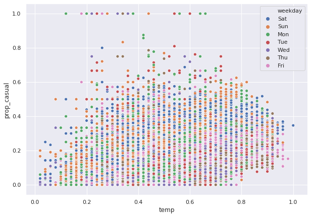

```python
plt.figure(figsize=(10, 7))
sns.scatterplot(data=bike, x="temp", y="prop_casual", hue="weekday");
```

[figure not shown]

```python
bike['temp'] = bike['temp']*41
graphdude = sns.lmplot(x='temp', y='prop_casual', data=bike, hue='weekday', scatter=False, lowess=True)
plt.figure(figsize=(8,6))
```

#### Observations

```python
print('The proportion of riders increases as the temperature increases')
```

```
The proportion of riders increases as the temperature increases
```

### Thank you for checking out this project. I hope you enjoyed it as much as I enjoyed making it!